# Assignment3

Okan Yıldırım

16 September 2020

# 1 Introduction

## 1.1 What is Diamond?

Diamond is a rare mineral consisting of carbon, which occurs naturally. Each carbon atom in a diamond is surrounded and bound by four other carbon atoms by strong covalent bonds-the strongest form of chemical bond. This simple, standardized, tightly bonded arrangement yields one of the most durable and versatile known substances.

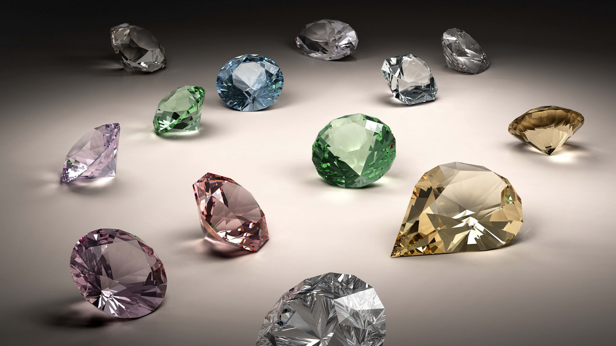

## 1.2 Diamond Quality

Diamonds are the most sought after gemstones in the world. Diamonds are spent several times more money than all other gemstones combined. Part of the explanation for the success of diamonds is because of their optical properties-or how it interacts with light. Other considerations include its diamond producers’ toughness, fashion, tradition and aggressive marketing.

# 2 Data Information, Loading and Preprocessing

## 2.1 Package Loading

```r
library(lubridate)
library(dplyr)
library(ggplot2)
library(knitr)
library(tibble)
library(kableExtra)
library(GGally)
```

In this analysis, we’ll use dplyr, ggplot2, knitr, tibble, and kableExtra packages.

## 2.2 Data Information

In this assignment we’ll use diamonds dataset in ggplot2 package. By using glimpse() function we can seek at diamonds dataset.

```r
diamonds %>% glimpse()
```

```
## Rows: 53,940
## Columns: 10
## $ carat   <dbl> 0.23, 0.21, 0.23, 0.29, 0.31, 0.24, 0.24, 0.26, 0.22, 0.23,...
## $ cut     <ord> Ideal, Premium, Good, Premium, Good, Very Good, Very Good, ...
## $ color   <ord> E, E, E, I, J, J, I, H, E, H, J, J, F, J, E, E, I, J, J, J,...
## $ clarity <ord> SI2, SI1, VS1, VS2, SI2, VVS2, VVS1, SI1, VS2, VS1, SI1, VS...
## $ depth   <dbl> 61.5, 59.8, 56.9, 62.4, 63.3, 62.8, 62.3, 61.9, 65.1, 59.4,...
## $ table   <dbl> 55, 61, 65, 58, 58, 57, 57, 55, 61, 61, 55, 56, 61, 54, 62,...
## $ price   <int> 326, 326, 327, 334, 335, 336, 336, 337, 337, 338, 339, 340,...
## $ x       <dbl> 3.95, 3.89, 4.05, 4.20, 4.34, 3.94, 3.95, 4.07, 3.87, 4.00,...
## $ y       <dbl> 3.98, 3.84, 4.07, 4.23, 4.35, 3.96, 3.98, 4.11, 3.78, 4.05,...
## $ z       <dbl> 2.43, 2.31, 2.31, 2.63, 2.75, 2.48, 2.47, 2.53, 2.49, 2.39,...
```

- price : price in US dollars ($326–$18,823)
- carat : weight of the diamond (0.2–5.01)
- cut : quality of the cut (Fair, Good, Very Good, Premium, Ideal)
- color : diamond colour, from J (worst) to D (best)
- clarity : a measurement of how clear the diamond is (I1 (worst), SI2, SI1, VS2, VS1, VVS2, VVS1, IF (best))
- x : length in mm (0–10.74)
- y : width in mm (0–58.9)
- z : depth in mm (0–31.8)
- depth : total depth percentage = z / mean(x, y) = 2 * z / (x + y) (43–79)
- table : width of top of diamond relative to widest point (43–95)

My goal is to provide useful exploratory data analysis (EDA) and to build a model for estimating the price of diamonds.